# Life Expectancy and Economic Development

## Overview

This analysis examines how life expectancy varies across countries based on income, demographics, and inequality. The processed dataset contains 193 country level observations from 2022, with no missing values for GDP per capita or life expectancy after cleaning.

## Exploratory analysis

GDP per capita is highly skewed, so I use a log transformation in the regression models. The transformed variable is more suitable for modeling because it compresses very high income observations and better reflects diminishing returns to income.

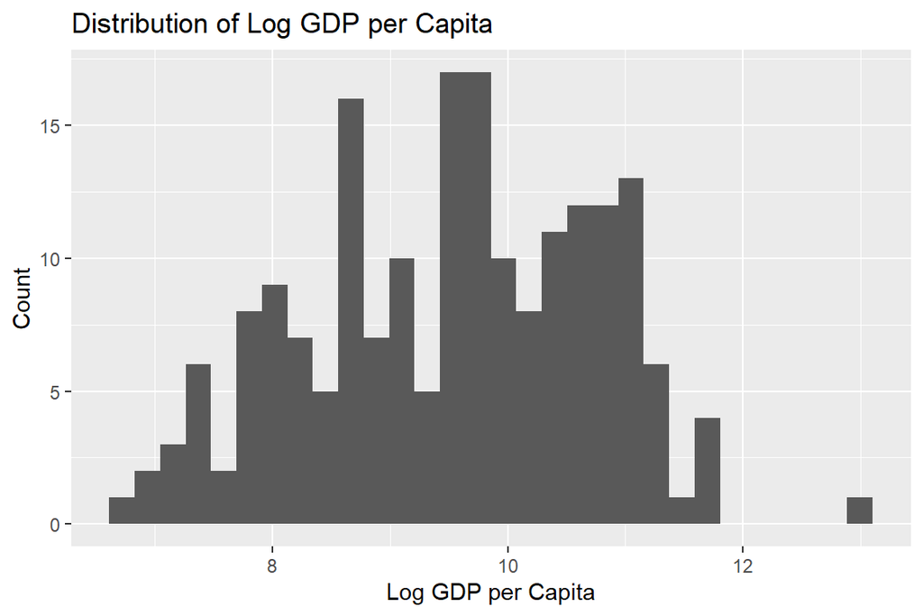

The correlation between life expectancy and log GDP per capita is 0.796, indicating a strong positive relationship and supporting the use of log GDP per capita in the model.

GDP per capita and average daily income are highly correlated (0.948), so I exclude average daily income to avoid redundancy.

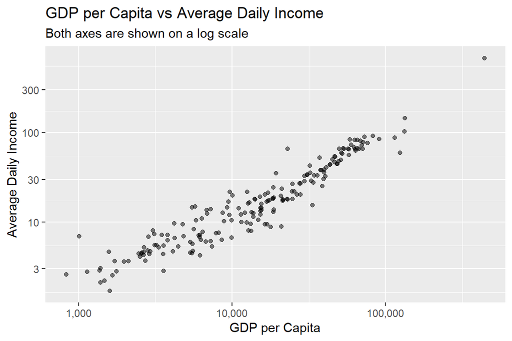

## Regression models

I build the analysis incrementally. The baseline model uses log GDP per capita. The demographic model adds fertility and median age. The inequality model adds the Gini coefficient. The final model excludes median age because it becomes less informative once inequality is included and exhibits multicollinearity with other predictors.

Adding demographics significantly improves model fit relative to the baseline model (F = 18.85, p < 0.001). Inequality also improves fit in both the expanded and final specifications (p < 0.001).

## Regression summary

Robust standard errors are used throughout to account for potential heteroskedasticity.

Regression Models of Life Expectancy

|  | Baseline | Demographics | Inequality | Final |
| --- | --- | --- | --- | --- |
| Intercept | 26.501*** | 46.327*** | 56.893*** | 59.131*** |
|  | (2.709) | (5.259) | (6.068) | (6.157) |
| Log GDP per Capita | 4.796*** | 2.415*** | 2.252*** | 2.660*** |
|  | (0.280) | (0.532) | (0.548) | (0.471) |
| Children per Woman |  | -1.274** | -1.541*** | -2.063*** |
|  |  | (0.480) | (0.449) | (0.401) |
| Median Age |  | 0.205** | 0.136+ |  |
|  |  | (0.078) | (0.075) |  |
| Gini Index |  |  | -0.159*** | -0.179*** |
|  |  |  | (0.047) | (0.047) |
| Num.Obs. | 193 | 193 | 193 | 193 |
| R2 | 0.633 | 0.694 | 0.717 | 0.711 |
| R2 Adj. | 0.631 | 0.689 | 0.711 | 0.707 |
| Std.Errors | HC1 | HC1 | HC1 | HC1 |

+ p < 0.1, * p < 0.05, ** p < 0.01, *** p < 0.001  
Robust standard errors (HC1) in parentheses.

## Diagnostics

The residuals vs. fitted values plot for the final model shows mild curvature but no strong pattern that would overturn the main interpretation. I interpret the results as descriptive associations and use robust standard errors throughout.

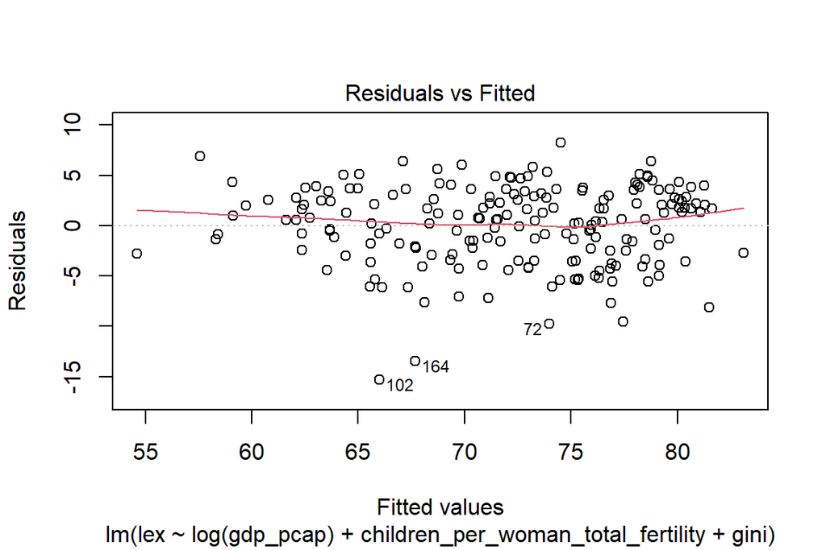

Median age shows moderate multicollinearity in the expanded inequality model (VIF = 5.36), which supports excluding it from the final specification.

More broadly, the model implies that countries with higher income, lower fertility, and lower inequality tend to have higher predicted life expectancy.

This is a cross-sectional analysis, so the results should be interpreted as descriptive associations rather than causal effects.

## Key takeaways

- GDP per capita is strongly and positively associated with life expectancy.
- Fertility is negatively associated with life expectancy and adds explanatory power beyond income.
- Inequality is negatively associated with life expectancy after accounting for income and fertility.
- Median age is excluded from the final model because it overlaps with other predictors and adds limited independent information.